# Introduction

- For this project, I chose to examine the outcome Poor Health, which represents the proportion of county that has a poor health status. I examined different demographic and social determinants of health at the county level in order to draw insights and comparisons between different characteristics. I chose to focus deeply on the interplay between Poor Health and Physical Inactivity in order to see their correlation and their relative association with similar factors such as adult obesity, food insecurity, proportion of smokers, and excessive drinkers. As someone who enjoys working out and eating healthy, I am interested to see the impact of physical inactivity on health outcomes and how it correlates with other factors in different counties in the US.

# Questions of Interest

1. How are poor health outcomes and physical inactivity related and how does this association change over food insecurity quartile?
1. How do other related factors like adult obesity, food insecurity, proportion of smokers, and excessive drinking relate to poor health outcomes, and how does their impact change when related to physical inactivity?
1. What do combined models reveal about poor health outcomes?

# Dataset and Health Summary

```
(2715, 26)
Five-digit.FIPS.Code                  int64
State.FIPS.Code                       int64
County.FIPS.Code                      int64
State.Abbreviation                   object
CountyName                           object
Poor.Health                         float64
Election.Results.2016                object
Uninsured                           float64
Primary.Care.Physicians.Per.1000    float64
Mental.health.providers.Per.1000    float64
Adult.Obesity                       float64
Proportion.of.Smokers               float64
High.School.Graduation              float64
Insufficient.Sleep                  float64
Physical.Inactivity                 float64
Excessive.Drinking                  float64
Median.Household.Income               int64
Severe.Housing.Problems             float64
Unemployment                        float64
Food.Insecurity.Quintile             object
Income.Inequality.Quartile           object
Percent.Rural                       float64
Over.65                             float64
Percent.Females                     float64
Life.Expectancy                     float64
Population                            int64
dtype: object
count    2715.000000
mean        0.174385
std         0.045176
min         0.082900
25%         0.140350
50%         0.167300
75%         0.203950
max         0.407300
Name: Poor.Health, dtype: float64
count    2715.000000
mean        0.255718
std         0.051730
min         0.084000
25%         0.221000
50%         0.256000
75%         0.291000
max         0.451000
Name: Physical.Inactivity, dtype: float64
```

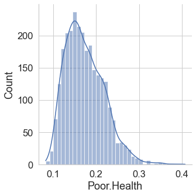

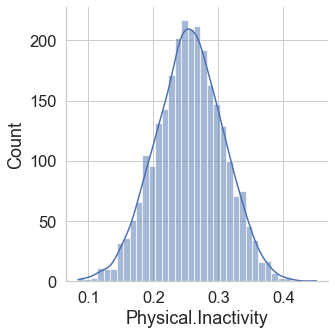

```python
##Summary
print(county_data.shape)
print(county_data.dtypes)

## Health Outcomes Summary
print(county_data['Poor.Health'].describe())
sns.displot(county_data['Poor.Health'],kde=True);

##Physical Inactivity
print(county_data['Physical.Inactivity'].describe())
sns.displot(county_data['Physical.Inactivity'],kde=True);
```

- First, I examined a summary of the dataset and the y variable Poor Health. I printed the dimensions of the dataset as well as the data types in order to gain an understanding of the data I am working with.
- I also examined the summary statistics of Poor Health. Notably, its mean value is .174 and its median value is .167. Since these values are close but the mean is greater, I wanted to investigate if the poor health distribution is right skewed. To do so, I plotted the distribution plot and saw that the distribution of poor health was skewed to the right, indicating that there are some counties with higher proportions of poor health that drags the distribution to the right.
- Next, I examined my other main variable of interest, Physical Inactivity. This value represents the proportion of population that is physically inactive. In the summary statistics, its mean and median is .256, which indicates that the distribution will be centrally distributed. After examining the distribution plot, this assumption is true.